# Class 8: Unsupervised Machine Learning

## Principal Component Analysis (PCA)

The PCs (i.e. new plot axis) are ranked by their importance. So, PC1 is more important than PC2, which in turn is more important than PC3, etc. The PCs are ranked by the amount of variance in the original data (i.e. gene expression values) that they “capture”

We actually get two main things out of a typical PCA: The new axis (called PCs or Eigenvectors) and Eigenvalues that detail the amount of variance captured by each PC.

PC Loadings: a quantitive report on how the original variables contributed to each PC, or in other words, which genes were most important to the observed clustering

Look at the following tutorial/guide to become more familiar with how PCA works: https://bioboot.github.io/bggn213_W19/class-material/pca/

**Lecture Example**

Note: there are many better PCA packages available in R, but today we will use base R **prcomp()** function.

The following example is from an RNAseq experiment.

```r
## You can also download this file from the class website
mydata <- read.csv("https://tinyurl.com/expression-CSV",
row.names=1)
head(mydata)
```

```
##        wt1 wt2  wt3  wt4 wt5 ko1 ko2 ko3 ko4 ko5
## gene1  439 458  408  429 420  90  88  86  90  93
## gene2  219 200  204  210 187 427 423 434 433 426
## gene3 1006 989 1030 1017 973 252 237 238 226 210
## gene4  783 792  829  856 760 849 856 835 885 894
## gene5  181 249  204  244 225 277 305 272 270 279
## gene6  460 502  491  491 493 612 594 577 618 638
```

```r
# NOTE: the samples are columns, and the genes are rows
```

There are 100 in this dataset. We can also see that there are wildtype and knockout lines being tested.

```r
 # lets do PCA
 pca <- prcomp(t(mydata), scale=TRUE)

 # Note: R expects the genes to be columns, and the samples to be in the rows, so we used t() to transpose the data first

 # See what is returned by the prcomp() function
 summary(pca)
```

```
## Importance of components:
##                           PC1    PC2     PC3     PC4     PC5     PC6
## Standard deviation     9.6237 1.5198 1.05787 1.05203 0.88062 0.82545
## Proportion of Variance 0.9262 0.0231 0.01119 0.01107 0.00775 0.00681
## Cumulative Proportion  0.9262 0.9493 0.96045 0.97152 0.97928 0.98609
##                            PC7     PC8     PC9      PC10
## Standard deviation     0.80111 0.62065 0.60342 3.348e-15
## Proportion of Variance 0.00642 0.00385 0.00364 0.000e+00
## Cumulative Proportion  0.99251 0.99636 1.00000 1.000e+00
```

Proportion of variance shows how much the PC is influencing overall variance, i.e PC1 explains 92.62% of the variance, and PC2 explains 2.31%.

```r
attributes(pca)
```

```
## $names
## [1] "sdev"     "rotation" "center"   "scale"    "x"
##
## $class
## [1] "prcomp"
```

The returned pca$x here contains the principal components (PCs) for drawing our first graph.

Let’s make the PCA plot.

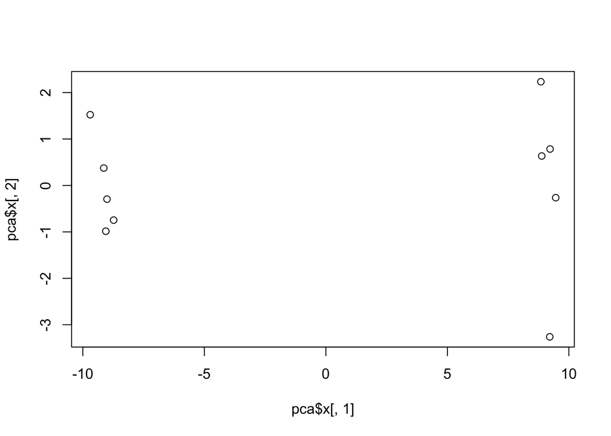

```r
#This is PCA1 on x axis vs. PCA2 on y axis (columns 1 and 2 of attribute x)
plot( pca$x[,1], pca$x[,2] )
```

Nice separation of samples into two groups of 5 samples each

```r
## Percent variance captured per PC
pca.var <- pca$sdev^2
pca.var.per <- round(pca.var/sum(pca.var)*100, 1)

pca.var.per
```

```
##  [1] 92.6  2.3  1.1  1.1  0.8  0.7  0.6  0.4  0.4  0.0
```

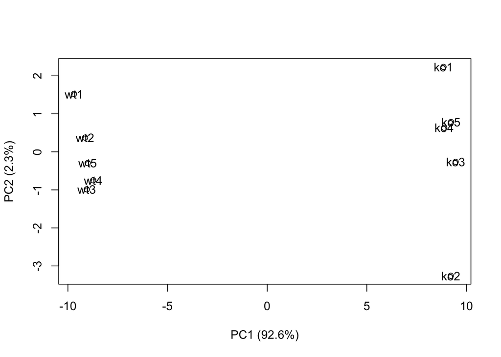

```r
#Make a nicer plot with our percent variance per PCA indicated on the axes
xlab <- paste("PC1 (",pca.var.per[1], "%)", sep = "" )
ylab <- paste("PC2 (",pca.var.per[2], "%)", sep = "" )

plot( pca$x[,1], pca$x[,2], xlab = xlab, ylab = ylab )

#adds sample name "wt1, ko1, etc" onto corresponding point
text( pca$x[,1], pca$x[,2], colnames(mydata))
```

## Hands-on with Principal Component Analysis (PCA)

Find the assignment here: https://bioboot.github.io/bggn213_W19/class-material/lab-8-bggn213.html

**Perform a PCA on the UK food data**

```r
x <- read.csv("https://bioboot.github.io/bggn213_f17/class-material/UK_foods.csv", row.names = 1)
```

**Q1. How many rows and columns are in your new data frame named x? What R functions could you use to answer this questions?**

```r
head(x)
```

```
##                England Wales Scotland N.Ireland
## Cheese             105   103      103        66
## Carcass_meat       245   227      242       267
## Other_meat         685   803      750       586
## Fish               147   160      122        93
## Fats_and_oils      193   235      184       209
## Sugars             156   175      147       139
```

```r
nrow(x)
```

```
## [1] 17
```

```r
ncol(x)
```

```
## [1] 4
```

**Note: went back and corrected from read.csv() so this command is now commented out.

```r
#rownames(x) <- x[,1]
#x <- x[,-1]
#head(x)
```

Now, the dataset is properly sorted.

**Q2. Which approach to solving the ‘row-names problem’ mentioned above do you prefer and why? Is one approach more robust than another under certain circumstances?**

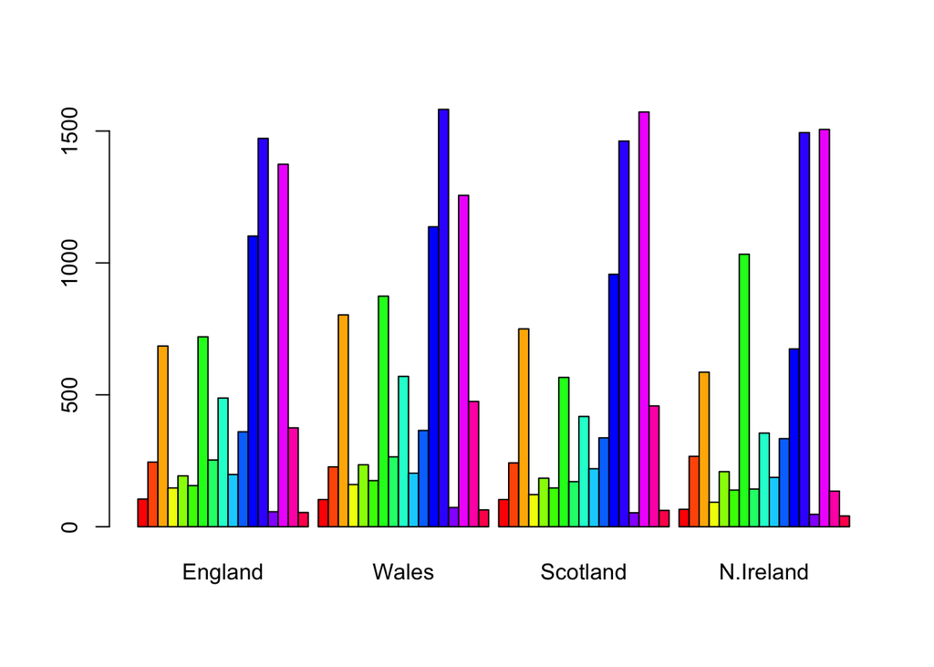

```r
# Make a barplot
barplot(as.matrix(x), beside=T, col=rainbow(nrow(x)))
```

**Q3: Changing what optional argument in the above barplot() function results in the following plot? (See document and barplot below)**

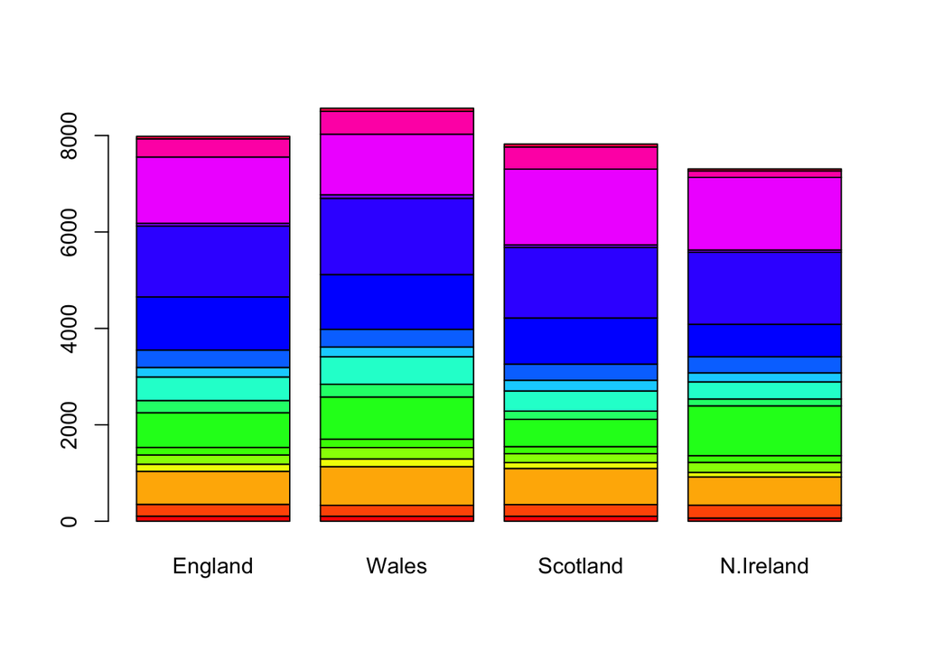

```r
#Change the "beside" argument
barplot(as.matrix(x), beside=F, col=rainbow(nrow(x)))
```

From the barplot() documentation: Beside is a logical value. If FALSE, the columns of height are portrayed as stacked bars, and if TRUE the columns are portrayed as juxtaposed bars.

**Q4: Generating all pairwise plots may help somewhat. Can you make sense of the following code and resulting figure? What does it mean if a given point lies on the diagonal for a given plot?**

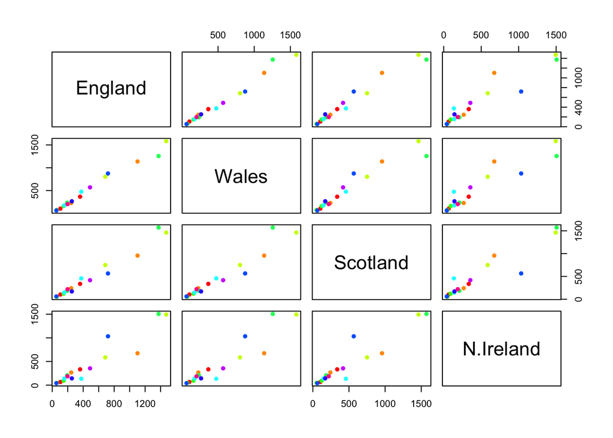

```r
#generates a matrix of scatterplots
pairs(x, col=rainbow(10), pch=16)
```

If values are on diagonal, they are the same between the two pairs. Can see a pattern in plots with Northern Ireland (points that deviate more from the diagonal).

**Q6. What is the main differences between N. Ireland and the other countries of the UK in terms of this data-set?**